# 10-important Steps for Exploratory Data Analyssis

1. Data Shape (columns or Rows ki taddad dekh len)
2. Check Data structure of each column or series
3. Missing values in each column and whole data set
4. Split variables or make new columns if needed
5. Type casting
6. Summary statistics
7. Value counts of a specific column
8. Deal with duplicates
9. Check the normal distribution of data (data Anomally)
10. Correlation between two variables (columns/series)

## EDA karne se hamen kia kia maloom hta hy?

1. Data invetigation
2. Patterns inside the data
3. Anomalies (normal disribution hy ya skewed)
4. hyothsis konsa or kaisay design karna
5. Assumption konsi hni chahyeayn
6. Data visualization (Sirf pattern dekhnay k liay)

```python
#import libararies
import numpy as np
import pandas as pd
import seaborn as sns
import scipy as sc
import matplotlib.pyplot as plt
```

```python
#load datasets
df= sns.load_dataset('tips')
df1= sns.load_dataset('titanic')
```

### 1.find shape

```python
# shape

rows, cols = df.shape
print("Number of Rows       = ", rows) #instances
print("Number of Columns    = ", cols) #series
```

```
Number of Rows       =  244
Number of Columns    =  7
```

```python
# shape

rows, cols = df1.shape
print("Number of Rows       = ", rows) #instances
print("Number of Columns    = ", cols) #series
```

```
Number of Rows       =  891
Number of Columns    =  15
```

### 2. Check Data structure of each column or series

```python
# info of data
df.info()
```

```
<class 'pandas.core.frame.DataFrame'>
RangeIndex: 244 entries, 0 to 243
Data columns (total 7 columns):
 #   Column      Non-Null Count  Dtype
---  ------      --------------  -----
 0   total_bill  244 non-null    float64
 1   tip         244 non-null    float64
 2   sex         244 non-null    category
 3   smoker      244 non-null    category
 4   day         244 non-null    category
 5   time        244 non-null    category
 6   size        244 non-null    int64
dtypes: category(4), float64(2), int64(1)
memory usage: 7.4 KB
```

```python
# data info
df1.info()
```

```
<class 'pandas.core.frame.DataFrame'>
RangeIndex: 891 entries, 0 to 890
Data columns (total 15 columns):
 #   Column       Non-Null Count  Dtype
---  ------       --------------  -----
 0   survived     891 non-null    int64
 1   pclass       891 non-null    int64
 2   sex          891 non-null    object
 3   age          714 non-null    float64
 4   sibsp        891 non-null    int64
 5   parch        891 non-null    int64
 6   fare         891 non-null    float64
 7   embarked     889 non-null    object
 8   class        891 non-null    category
 9   who          891 non-null    object
 10  adult_male   891 non-null    bool
 11  deck         203 non-null    category
 12  embark_town  889 non-null    object
 13  alive        891 non-null    object
 14  alone        891 non-null    bool
dtypes: bool(2), category(2), float64(2), int64(4), object(5)
memory usage: 80.7+ KB
```

### 3. Missing values in each column and whole data set

```python
# how many missing values present
df.isnull().sum()
```

```
total_bill    0
tip           0
sex           0
smoker        0
day           0
time          0
size          0
dtype: int64
```

```python
# how many missing values present
df1.isnull().sum()
```

```
survived         0
pclass           0
sex              0
age            177
sibsp            0
parch            0
fare             0
embarked         2
class            0
who              0
adult_male       0
deck           688
embark_town      2
alive            0
alone            0
dtype: int64
```

We will calculated the percentage of missing values, and if the percentage of missing value is high then we will reduce the priority of that column. We can dealwith the missing values if the percentage is low by replacing them with the means, median or other methods (removal).

```python
# percentage of missing values
df.isnull().sum() / df.shape[0] *100
```

```
total_bill    0.0
tip           0.0
sex           0.0
smoker        0.0
day           0.0
time          0.0
size          0.0
dtype: float64
```

```python
# percentage of missing values
df1.isnull().sum() / df.shape[0] *100
```

```
survived         0.000000
pclass           0.000000
sex              0.000000
age             72.540984
sibsp            0.000000
parch            0.000000
fare             0.000000
embarked         0.819672
class            0.000000
who              0.000000
adult_male       0.000000
deck           281.967213
embark_town      0.819672
alive            0.000000
alone            0.000000
dtype: float64
```

### 4. Split variables or make new columns if needed

```python
# making a dataframe for example using pandas library

df2 = pd.DataFrame(np.array([["Lahore, Pakistan",67, 100], ["Beijing, China", 5, 6], ["berlin, Germany", 8, 9]]),
                   columns=['address', 'males', 'females'])
df2.head()
```

|  | address | males | females |
| --- | --- | --- | --- |
| 0 | Lahore, Pakistan | 67 | 100 |
| 1 | Beijing, China | 5 | 6 |
| 2 | berlin, Germany | 8 | 9 |

```python
# if we want to separate address into city and country columns we will split like this
df2[['city', 'country']] = df2['address'].str.split(',', expand=True)
#to see the results
df2.head()
```

|  | address | males | females | city | country |
| --- | --- | --- | --- | --- | --- |
| 0 | Lahore, Pakistan | 67 | 100 | Lahore | Pakistan |
| 1 | Beijing, China | 5 | 6 | Beijing | China |
| 2 | berlin, Germany | 8 | 9 | berlin | Germany |

### 5. Type casting

```python
# how to see the types in first place
df2.info()
```

```
<class 'pandas.core.frame.DataFrame'>
RangeIndex: 3 entries, 0 to 2
Data columns (total 5 columns):
 #   Column   Non-Null Count  Dtype
---  ------   --------------  -----
 0   address  3 non-null      object
 1   males    3 non-null      object
 2   females  3 non-null      object
 3   city     3 non-null      object
 4   country  3 non-null      object
dtypes: object(5)
memory usage: 248.0+ bytes
```

```python
# convert data type into integer
df2[['males', 'females']] = df2[['males', 'females']].astype('int')
#convert to string
df2[["city", "country"]] = df2[["city", "country"]].astype('str').astype("string")
```

```python
df2.info()
```

```
<class 'pandas.core.frame.DataFrame'>
RangeIndex: 3 entries, 0 to 2
Data columns (total 5 columns):
 #   Column   Non-Null Count  Dtype
---  ------   --------------  -----
 0   address  3 non-null      object
 1   males    3 non-null      int32
 2   females  3 non-null      int32
 3   city     3 non-null      string
 4   country  3 non-null      string
dtypes: int32(2), object(1), string(2)
memory usage: 224.0+ bytes
```

```python
# #Replace Data Types to Boolean
# df["IsPurchased"] = df['IsPurchased'].astype('bool')
# #Replace Data Types to Float
# df["Total Spend"] = df['Total Spend'].astype('float')
# #Replace Data Types to Datetime with format= '%Y%m%d'
# df['Dates'] = pd.to_datetime(df['Dates'], format='%Y%m%d')
```

### 6. Summary statistics

```python
df.describe()
```

|  | total_bill | tip | size |
| --- | --- | --- | --- |
| count | 244.000000 | 244.000000 | 244.000000 |
| mean | 19.785943 | 2.998279 | 2.569672 |
| std | 8.902412 | 1.383638 | 0.951100 |
| min | 3.070000 | 1.000000 | 1.000000 |
| 25% | 13.347500 | 2.000000 | 2.000000 |
| 50% | 17.795000 | 2.900000 | 2.000000 |
| 75% | 24.127500 | 3.562500 | 3.000000 |
| max | 50.810000 | 10.000000 | 6.000000 |

```python
df1.describe()
```

|  | survived | pclass | age | sibsp | parch | fare |
| --- | --- | --- | --- | --- | --- | --- |
| count | 891.000000 | 891.000000 | 714.000000 | 891.000000 | 891.000000 | 891.000000 |
| mean | 0.383838 | 2.308642 | 29.699118 | 0.523008 | 0.381594 | 32.204208 |
| std | 0.486592 | 0.836071 | 14.526497 | 1.102743 | 0.806057 | 49.693429 |
| min | 0.000000 | 1.000000 | 0.420000 | 0.000000 | 0.000000 | 0.000000 |
| 25% | 0.000000 | 2.000000 | 20.125000 | 0.000000 | 0.000000 | 7.910400 |
| 50% | 0.000000 | 3.000000 | 28.000000 | 0.000000 | 0.000000 | 14.454200 |
| 75% | 1.000000 | 3.000000 | 38.000000 | 1.000000 | 0.000000 | 31.000000 |
| max | 1.000000 | 3.000000 | 80.000000 | 8.000000 | 6.000000 | 512.329200 |

```python
df2.describe()
```

|  | males | females |
| --- | --- | --- |
| count | 3.000000 | 3.000000 |
| mean | 26.666667 | 38.333333 |
| std | 34.961884 | 53.425961 |
| min | 5.000000 | 6.000000 |
| 25% | 6.500000 | 7.500000 |
| 50% | 8.000000 | 9.000000 |
| 75% | 37.500000 | 54.500000 |
| max | 67.000000 | 100.000000 |

### 7. Value counts of a specific column

```python
#how much values in a specific column
df1['age'].value_counts()
```

```
24.00    30
22.00    27
18.00    26
19.00    25
28.00    25
         ..
36.50     1
55.50     1
0.92      1
23.50     1
74.00     1
Name: age, Length: 88, dtype: int64
```

```python
df2['females'].value_counts()
```

```
100    1
6      1
9      1
Name: females, dtype: int64
```

```python
df['tip'].value_counts()
```

```
2.00    33
3.00    23
4.00    12
5.00    10
2.50    10
        ..
4.34     1
1.56     1
5.20     1
2.60     1
1.75     1
Name: tip, Length: 123, dtype: int64
```

```python
#finding unique values in a column or series
df1['age'].unique()
```

```
array([22.  , 38.  , 26.  , 35.  ,   nan, 54.  ,  2.  , 27.  , 14.  ,
        4.  , 58.  , 20.  , 39.  , 55.  , 31.  , 34.  , 15.  , 28.  ,
        8.  , 19.  , 40.  , 66.  , 42.  , 21.  , 18.  ,  3.  ,  7.  ,
       49.  , 29.  , 65.  , 28.5 ,  5.  , 11.  , 45.  , 17.  , 32.  ,
       16.  , 25.  ,  0.83, 30.  , 33.  , 23.  , 24.  , 46.  , 59.  ,
       71.  , 37.  , 47.  , 14.5 , 70.5 , 32.5 , 12.  ,  9.  , 36.5 ,
       51.  , 55.5 , 40.5 , 44.  ,  1.  , 61.  , 56.  , 50.  , 36.  ,
       45.5 , 20.5 , 62.  , 41.  , 52.  , 63.  , 23.5 ,  0.92, 43.  ,
       60.  , 10.  , 64.  , 13.  , 48.  ,  0.75, 53.  , 57.  , 80.  ,
       70.  , 24.5 ,  6.  ,  0.67, 30.5 ,  0.42, 34.5 , 74.  ])
```

```python
df2['females'].unique()
```

```
array([100,   6,   9])
```

### 8. Deal with duplicates

```python
# find duplicates (remove)/ null values ( mean median mode)
df1[df1.embark_town == 'Queenstown']

#this will show the people only embarked from Queenstown in Titanic.
```

|  | survived | pclass | sex | age | sibsp | parch | fare | embarked | class | who | adult_male | deck | embark_town | alive | alone |
| --- | --- | --- | --- | --- | --- | --- | --- | --- | --- | --- | --- | --- | --- | --- | --- |
| 5 | 0 | 3 | male | NaN | 0 | 0 | 8.4583 | Q | Third | man | True | NaN | Queenstown | no | True |
| 16 | 0 | 3 | male | 2.0 | 4 | 1 | 29.1250 | Q | Third | child | False | NaN | Queenstown | no | False |
| 22 | 1 | 3 | female | 15.0 | 0 | 0 | 8.0292 | Q | Third | child | False | NaN | Queenstown | yes | True |
| 28 | 1 | 3 | female | NaN | 0 | 0 | 7.8792 | Q | Third | woman | False | NaN | Queenstown | yes | True |
| 32 | 1 | 3 | female | NaN | 0 | 0 | 7.7500 | Q | Third | woman | False | NaN | Queenstown | yes | True |
| ... | ... | ... | ... | ... | ... | ... | ... | ... | ... | ... | ... | ... | ... | ... | ... |
| 790 | 0 | 3 | male | NaN | 0 | 0 | 7.7500 | Q | Third | man | True | NaN | Queenstown | no | True |
| 825 | 0 | 3 | male | NaN | 0 | 0 | 6.9500 | Q | Third | man | True | NaN | Queenstown | no | True |
| 828 | 1 | 3 | male | NaN | 0 | 0 | 7.7500 | Q | Third | man | True | NaN | Queenstown | yes | True |
| 885 | 0 | 3 | female | 39.0 | 0 | 5 | 29.1250 | Q | Third | woman | False | NaN | Queenstown | no | False |
| 890 | 0 | 3 | male | 32.0 | 0 | 0 | 7.7500 | Q | Third | man | True | NaN | Queenstown | no | True |

77 rows × 15 columns

### 9. Check the normal distribution of data (data Anomally)

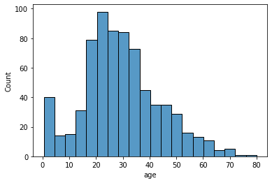

```python
# plot histogram
sns.histplot(df1['age'])
```

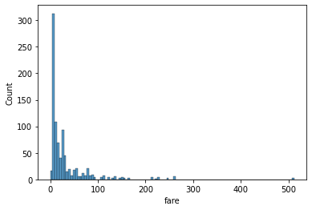

```python
sns.histplot(df1['fare'])
```

This one is right skewed and dosen't normal at all

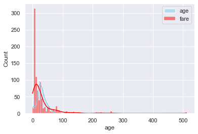

```python
# Plotting 2 variables on the same graph

# set a grey background
sns.set(style="darkgrid")

sns.histplot(data=df1, x="age", color="skyblue", label="age", kde=True)
sns.histplot(data=df1, x="fare", color="red", label="fare", kde=True)

plt.legend()
plt.show()
```

The gragh is looking messy because fare is not normally distributed and have outliers Thats why it is better to look at them individually first.

```python
df.head(2)
```

|  | total_bill | tip | sex | smoker | day | time | size |
| --- | --- | --- | --- | --- | --- | --- | --- |
| 0 | 16.99 | 1.01 | Female | No | Sun | Dinner | 2 |
| 1 | 10.34 | 1.66 | Male | No | Sun | Dinner | 3 |

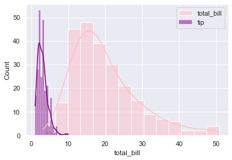

```python
# Plotting 2 variables on the same graph

# set a grey background
sns.set(style="darkgrid")

sns.histplot(data=df, x="total_bill", color="pink", label="total_bill", kde=True)
sns.histplot(data=df, x="tip", color="purple", label="tip", kde=True)

plt.legend()
plt.show()
```

```python
#measure its skewness and kurtosis
df1['age'].agg(['skew', 'kurtosis']).transpose()
```

```
skew        0.389108
kurtosis    0.178274
Name: age, dtype: float64
```

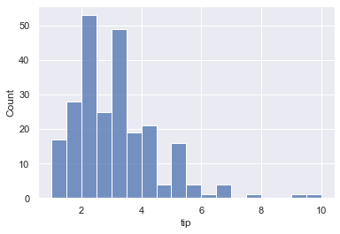

```python
sns.histplot(df['tip'])
```

```python
#measure its skewness and kurtosis
df['tip'].agg(['skew', 'kurtosis']).transpose()
```

```
skew        1.465451
kurtosis    3.648376
Name: tip, dtype: float64
```

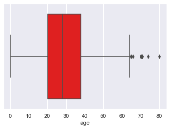

```python
sns.boxplot(df1['age'], color="red")
```

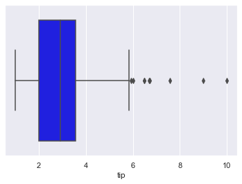

```python
sns.boxplot(df['tip'], color="blue")
```